# STATS 506 Final Project

Chuwen Li

12/15/2020

# Introduction

Nowadays there is a growing trend in formula feeding as the nutritional composition of infant formula is increasingly close to that of breast milk and more young mothers get depressed from breastfeeding pain. Still, lots of parents are worried or blamed by their parents for risking infants’ health by only choose formula feeding. There is no doubt that many merits associated with breastfeeding, including reducing risk of asthma and infections. Some of which are scientifically proved while others are widely various in opinions. This project aims to answer one of the widespread breastfeeding questions:

**Does breastfeeding prevent early childhood overweight?**

The analysis is based on fitting linear models with body measure index (BMI) as the dependent variable, and the explanatory factors as covariates, including sex, ethnicity, ever breastfed, mother smoked during pregnancy. The target group is 3 to 6 years old children.

# Data/Methods

The data used is from the National Health and Nutrition Examination Survey ([NHANES](https://wwwn.cdc.gov/nchs/nhanes/continuousnhanes/default.aspx?BeginYear=2017)). Specific data sets used are: Demographic data on the participants, health and nutrition examination survey on the participants, the answers to a diet behavior questionnaire, the answers to a early childhood questionnaire.

The analysis was performed using the “survey” package in R, which involves primary sampling unit, strata, and survey weights adjustment. The code for the analysis is available [here](https://github.com/lixx4228/Stats506_public). Two types of linear models were considered. The first one was taking the predict variable as a continuous outcome. The second model used a newly created binary variable: ‘overweight’ as the predictor, which took BMI greater and equal to 90th percentile as 1, and 0 otherwise. Both models were fitted with age, sex, ethnicity, mother ever smoked during pregnancy, and ever being breastfed. Figure 1 shows simple means for each explanatory variable with BMI.

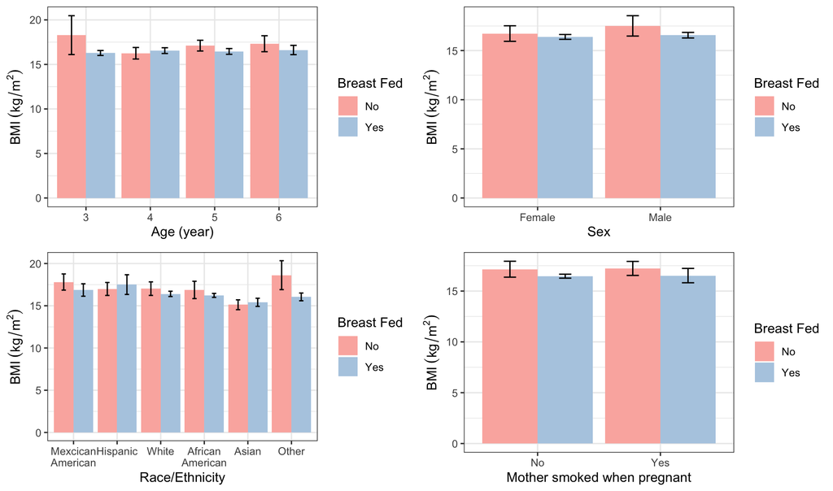

**Figure 1.** *BMI against age, sex, ethnicity, and momther smoked during pregnancy between 3-to-6-year-old breastfed and non-breastfed children, 2017-2018.*

# Results

Table 1 displays the summary results for logistic regression model and OLS model. For the OLS model, a natural spline with 2 knots was applied to the ‘Birth weight’ variable. Both models showed a negative association between breastfed children and being overweight or BMI gains with those younger than 6, of which parameters are statistically significant for 95% confidence level. There was a reduced risk of being overweight for breastfed children and based on the odds ratio, the risk was around 0.5 times smaller (95% CI, 0.37 - 0.75). The OLS model gave a result of 0.7 less BMI value for an ever breastfed child compared to a never breastfed child, holding all other variables constant. For other variables, age was positively associated with overweight in the logistic model but it was not significant in the OLS model. In the data, no Asian ethnicity children whose BMI exceeded 90 percentile.

# Conclusion

National data obtained from children (3-6 years) in 2017 and 2018 show ever breastfed children are less likely to experience early childhood overweight (BMI exceeds 90 percentile) compared to children who are only fed with formula. This result, however, does not entirely consistent with previous overweight and breastfeeding association study on 1998-1994 NHANES data (Hediger et al., 2001). Hediger, et. al. used BMI exceeded 95 percentile as the indicator of overweight and found no reduced risk of being overweight between breastfed and non-breastfed children. Due to the technical difficulty of combining survey weights and mixed models in R, my study is limited to simple linear models. Thus, future application of mixed model to this data set is a field of interest.

**Table 1.** *Statistical summary of logistic model and OLS model.*

|  | Overweight (BMI ≥ 90th Percentile) |  |  | BMI (kg/m²) |  |  |
| --- | --- | --- | --- | --- | --- | --- |
| Predictors | Odds Ratios | CI | p | Estimates | CI | p |
| (Intercept) | 0.019 | 0.003 – 0.103 | **0.006** | 16.000 | 14.561 – 17.438 | **<0.001** |
| Breastfed[Yes] | 0.523 | 0.366 – 0.748 | **0.016** | -0.696 | -1.050 – -0.341 | **0.018** |
| Birth weight, pounds | 1.170 | 0.945 – 1.448 | 0.209 |  |  |  |
| Age, years | 1.482 | 1.204 – 1.823 | **0.014** | 0.048 | -0.125 – 0.221 | 0.616 |
| Sex[Male] | 1.245 | 0.585 – 2.650 | 0.595 | 0.258 | -0.203 – 0.720 | 0.334 |
| Ethnicity[Hispanic] | 1.283 | 0.313 – 5.262 | 0.743 | 0.422 | -0.874 – 1.717 | 0.558 |
| Ethnicity[White] | 0.321 | 0.128 – 0.810 | 0.061 | -0.593 | -1.343 – 0.158 | 0.196 |
| Ethnicity[AfricanAmerican] | 0.285 | 0.113 – 0.724 | **0.046** | -0.576 | -1.311 – 0.159 | 0.199 |
| Ethnicity[Asian] | 0.000 | 0.000 – 0.000 | **<0.001** | -1.514 | -2.484 – -0.544 | **0.038** |
| Ethnicity[Other] | 0.601 | 0.231 – 1.559 | 0.343 | -0.569 | -1.475 – 0.337 | 0.286 |
| Mother smoked when pregnant[Yes] | 1.121 | 0.629 – 1.997 | 0.715 | 0.189 | -0.319 – 0.697 | 0.507 |
| ns(Birth weight, 2)[1] |  |  |  | 2.982 | 1.587 – 4.377 | **0.014** |
| ns(Birth weight, 2)[2] |  |  |  | 1.541 | 0.341 – 2.741 | 0.066 |
| Observations | 625 |  |  | 625 |  |  |
| R<sup>2</sup> / R<sup>2</sup> adjusted | 0.102 / -111.048 |  |  | 0.078 / -142.773 |  |  |

# Reference

[1] Hediger ML, Overpeck MD, Kuczmarski RJ, Ruan WJ. Association Between Infant Breastfeeding and Overweight in Young Children. *JAMA*. 2001;285(19):2453–2460. doi:10.1001/jama.285.19.2453